# What are countries doing to promote open science?

**By Carthage Smith and David Howoldt**  
31<sup>st</sup> July, 2024

[figure not shown]

### The STIP Compass and Open Science

Open science is a policy priority for all OECD countries. It is commonly accepted that expanding access to scientific information and data can not only improve the rigour and efficiency of science but can also accelerate innovation. Increased transparency and openness are also seen as important for enhancing understanding and trust in science for government decision-makers and the civil society more broadly. Indeed, in the aftermath of the COVID-19 pandemic, it is clear that public communication and engagement are a critical third pillar of open science on a par with open access to publications and FAIR (Findable, Accessible, Interoperable and reusable) data.

So, what are STI policymakers actually doing to support a transition to a more open scientific enterprise? How can embedded scientific practices and culture be shifted and the opportunities of digitalisation be embraced across all scientific domains? The OECD-EC STIP Compass database provides a window – albeit partial– into how different countries are responding at the national policy level to promote Open Science. The Open Science policies portal that was launched in April 2024, provides access to over 560 policy initiatives from 56 countries and is regularly updated. Whilst the information is certainly not fully comprehensive for all countries, it does provide a meta-view of where countries are focussing their efforts and, at the level of individual initiatives, it provides access to summary information and links that are a valuable starting point for those who want to delve further. Soon to come updates to the portal will also provide ready access to the published reports and articles relating to Open Science policy from OECD, other international organisations and relevant public repositories.

This short analysis first considers the broader strategies that countries are using to promote open science, before turning to a more detailed examination of two key categories of policy instruments: Collaborative Infrastructures and Governance. Collaborative Infrastructure instruments, such as open access repositories, collaborative platforms or information services, are essential for promoting interoperability and reusability of research data and engaging multiple stakeholders. Governance instruments, including the creation or reform of governance structures and formal consultation of stakeholders or experts are key for promoting cultural change within the scientific community. They are also important for ensuring that open science policies are aligned with broader STI policy objectives.

### STI strategies and Open Science

The open science portal reveals a robust international commitment to open science, encapsulated in 167 distinct national STI strategy documents.. Many of these are focused exclusively on Open Science. These various strategies envisage Opens Science as a way to enhance R&D capacity and output, maximize socio-economic impact and foster dialogue between scientific communities and societal stakeholders. Key objectives include promoting the sharing and reuse of scientific outputs and solutions, and leveraging multi-stakeholder engagement to drive this process. The different strategies demonstrate how countries are integrating open science principles to align scientific research with broader societal needs and economic growth, reflecting widespread recognition of open science as a critical driver of innovation and resilience in addressing contemporary challenges.

### Access to publications and data

A high-level analysis shows that most countries are implementing a range of policy initiatives to improve access to scientific publications and/or research data. In many cases these initiatives cut across both fields, which is not surprising as for much research data, an associated published article can effectively be considered as its detailed meta-data. Hence, almost all countries are making substantial investments in infrastructures, and often via multiple different initiatives, to support access to publications and data. The most common approach is to support information services and open access repositories. A significant number of countries are also providing dedicated support to more specialised research and technical infrastructures to enable greater access to their data. And there is also considerable investment that is more explicitly focused on networking and collaborative platforms.

**Figure 1: Access to research data and publications, Collaborative infrastructures instruments**

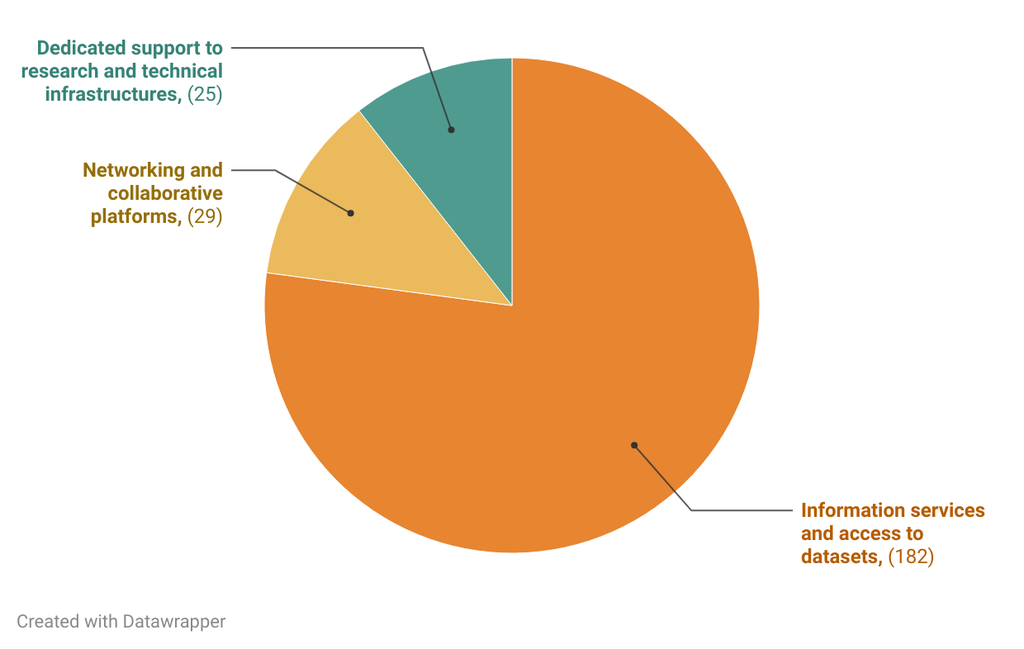

**Figure 2: Access to research data and publications, Governance instruments**

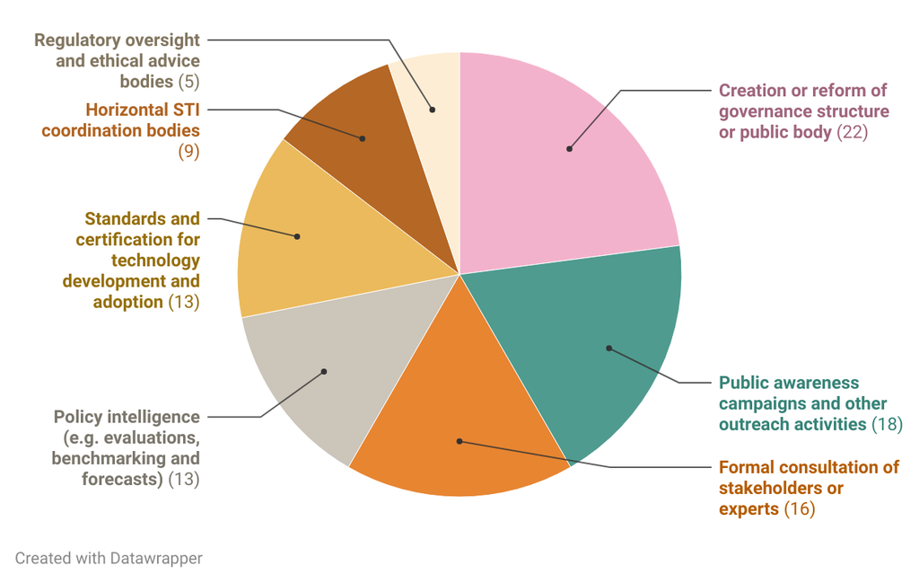

### Multi-stakeholder and public engagement

**Figure 3: Multi-stakeholder engagement instruments**

[figure not shown]

### STI Culture

In order to make Open Science a reality – make the output of science more widely available and useable and embrace public engagement – there needs to be a significant shift in STI practices and culture. This relates directly to the ‘Governance’ of STI and it is not surprising that this is the area where most countries are concentrating their policy effort. After two centuries or more of conducting STI in an analogue world the digital transition has transformed both the internal operations of science and the potential for interaction with other stakeholders. The transformation is almost certainly not yet complete and massive disruptions such as the COVID pandemic and environmental crisis are imposing new and more urgent demands for science, and the benefits of STI, to be more open. In this context, public awareness and outreach activities are currently, and by far, the most commonly deployed governance policy instruments relating to STI culture. Consultation, discussion and dialogue are essential both to inform cultural change and to enable and promote that change. Some countries have moved beyond this at the national policy level and taken other actions to promote support cultural change, including the development of collaborative platforms and information services or in a small number of cases embedding cultural change into the establishment or reform of national STI governance structures or bodies.

**Figure 4: STI culture instruments**

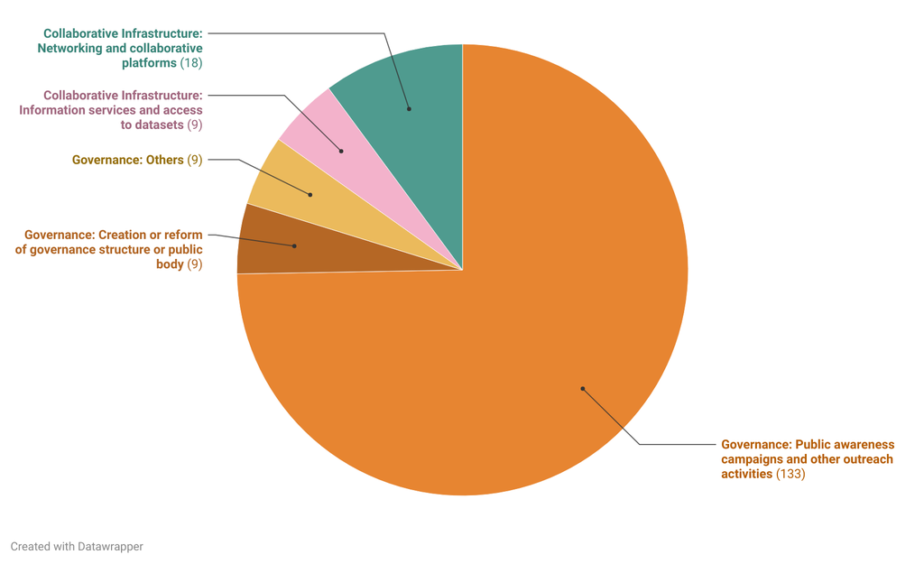

### Conclusion

The analysis of policy instruments in the OECD-EC STIP Compass Open Science Policies Portal reveals a diverse array of approaches to promoting open science across countries. The interplay between specific policy instruments, such as formal consultation of stakeholders or experts, the creation or reform of governance structures or public bodies, and public awareness campaigns, is likely to be an important factor in achieving effective outcomes. Deploying acombination of synergistic policy tools addressing different aspects of open science can be expected to have a multiplier effect in promoting open science.

As countries continue to prioritise open science, it is essential to monitor and evaluate the efficacy of these policy instruments in driving cultural change within the scientific community -enhancing access to scientific publications and data and promoting effective citizen engagement. The OECD-EC STIP Compass database and Open Science policies portal provide valuable resources for policymakers and researchers to explore and learn from the experiences of other countries, and to identify best practices and areas for improvement in promoting open science.

**Table 1: Details on ‘Other’ instruments in multi-stakeholder engagement initiatives**

| Policy instrument type category | Policy instrument type | Count |
| --- | --- | --- |
| Collaborative infrastructures (soft and physical) | Networking and collaborative platforms | 24 |
| Collaborative infrastructures (soft and physical) | Information services and access to datasets | 10 |
| Collaborative infrastructures (soft and physical) | Dedicated support to research and technical infrastructures | 2 |
| Governance | Public awareness campaigns and other outreach activities | 25 |
| Governance | Formal consultation of stakeholders or experts | 13 |
| Governance | Policy intelligence (e.g. evaluations, benchmarking and forecasts) | 11 |
| Governance | Horizontal STI coordination bodies | 9 |
| Governance | Creation or reform of governance structure or public body | 5 |
| Governance | Regulatory oversight and ethical advice bodies | 4 |
| Governance | Standards and certification for technology development and adoption | 1 |

**Table 2: Details on ‘Other’ instruments in STI Culture initiatives**

| Policy instrument type category | Policy instrument type | Count |
| --- | --- | --- |
| Collaborative infrastructures (soft and physical) | Networking and collaborative platforms | 18 |
| Collaborative infrastructures (soft and physical) | Information services and access to datasets | 9 |
| Governance | Public awareness campaigns and other outreach activities | 133 |
| Governance | Creation or reform of governance structure or public body | 9 |
| Governance | Policy intelligence (e.g. evaluations, benchmarking and forecasts) | 4 |
| Governance | Horizontal STI coordination bodies | 2 |
| Governance | Regulatory oversight and ethical advice bodies | 2 |
| Governance | Formal consultation of stakeholders or experts | 1 |